# HSF Knockdown and Nab-Paclitaxel Effects on PDCL5 Kinome Signaling_STK

Dr. Su

Cognitive Disorders Research Lab

19 August, 2026

# Introduction

## Background

The Pamstation12 instrument provides a profiling of kinase activity of cell or tissue samples. The device is loaded with either serine/threonine or tyrosine microarray chips. Each chip has 4 wells, so four samples can be loaded on a single chip, and the Pamstation12 can accommodate 3 chips per run. The microarray represents 144 (STK chip) or 196 (PTK chip) reporter peptides that can be phosphorylated by serine/threonine or tyrosine kinases. The device measures the degree of the phosphorylation in real time by detecting fluorescent labeled antibodies at different exposure times. The list of peptides present in each microarray can be viewed here: [STK chip](https://pamgene.com/wp-content/uploads/2020/09/STK-144-PamChip-87102.pdf), [PTK chip](https://pamgene.com/wp-content/uploads/2020/09/PTK-196-PamChip-86402.pdf)

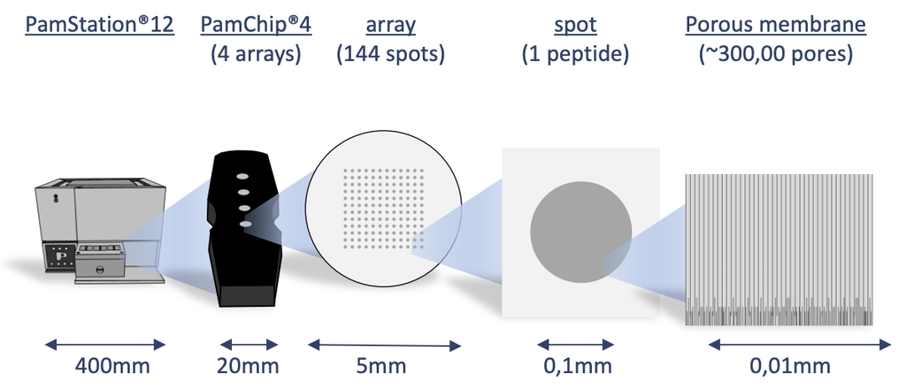

PamGene Kinase Activity Platform

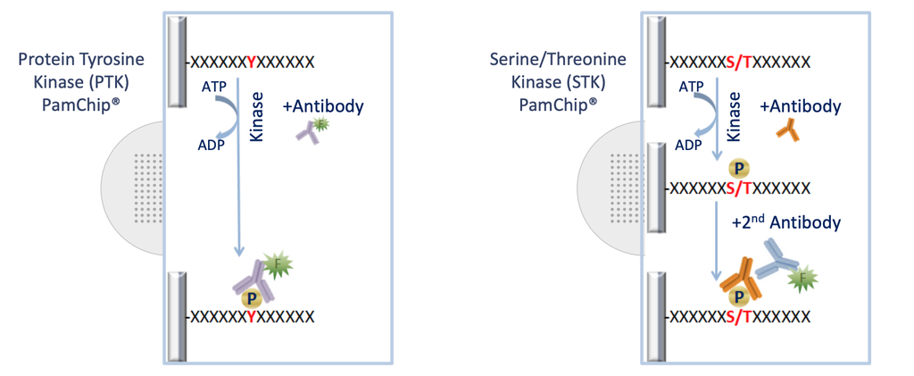

PamGene Platform Detection

# Run Design

Designing the placement of the samples on the chips and arrays is important to consider due to the variability across different chips and batches. During the run some wells are subject to fail and their data cannot be analyzed and shown below as red.

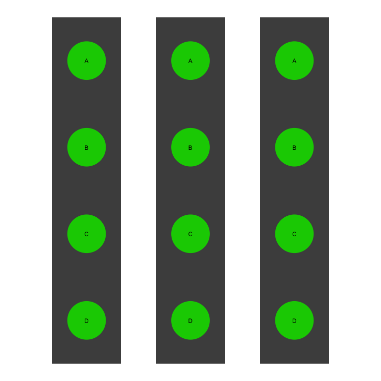

# Results

## Image Analysis

The first step of analyzing the run is to convert the images taken by the PamStation of each array at different exposure times to numerical values. This is done by the Bionavigator software developed by PamGene. The software recognizes the grid of the array with the aid of the searching algorithm (Pamgrid) to correctly identify each spot on the array. The numbers produced by this software represent the median value of the foreground pixels minus the median value of the background pixels to produce the median signal minus background (Median_SigmBg).

## Reading Data

The first step will be reading the crosstab view bionavigator files (Median_SigmBg and Signal_Saturation) and defining the PamChip type (STK or PTK). The raw data is read and then transformed to be in tidy format for an easier analysis, modeling, and visualizing.

## QC Initial Steps and Groups Assignments

We will perform a couple of quality control steps to deal with negative values in the data and adjust based on signal saturation (optional). Next, we will define a new column to represent the grouping. And then, we will extract end point signal values

## QC Steps and Model Fitting

We will filter out peptides with low signals. In order to combine the values from different exposure times into a single value, a simple linear regression model of the *Median_SigmBg* as a function of exposure time is fitted. The slope of of the model fit and $R^2$ are then used for quality control and samples comparison. The slope is also scaled by multiplying by 100 and log2 transformed (*Slope_Transformed*). We then filter out peptides with poor linear fit and references peptides.

## Global Signal Intensity

For a global signal intensity across all samples/groups, few figures can be plotted based on the *Slope_Transformed* values.

### Global Violin Plots

We will plot violin figures to examine global signal differences between groups/samples.

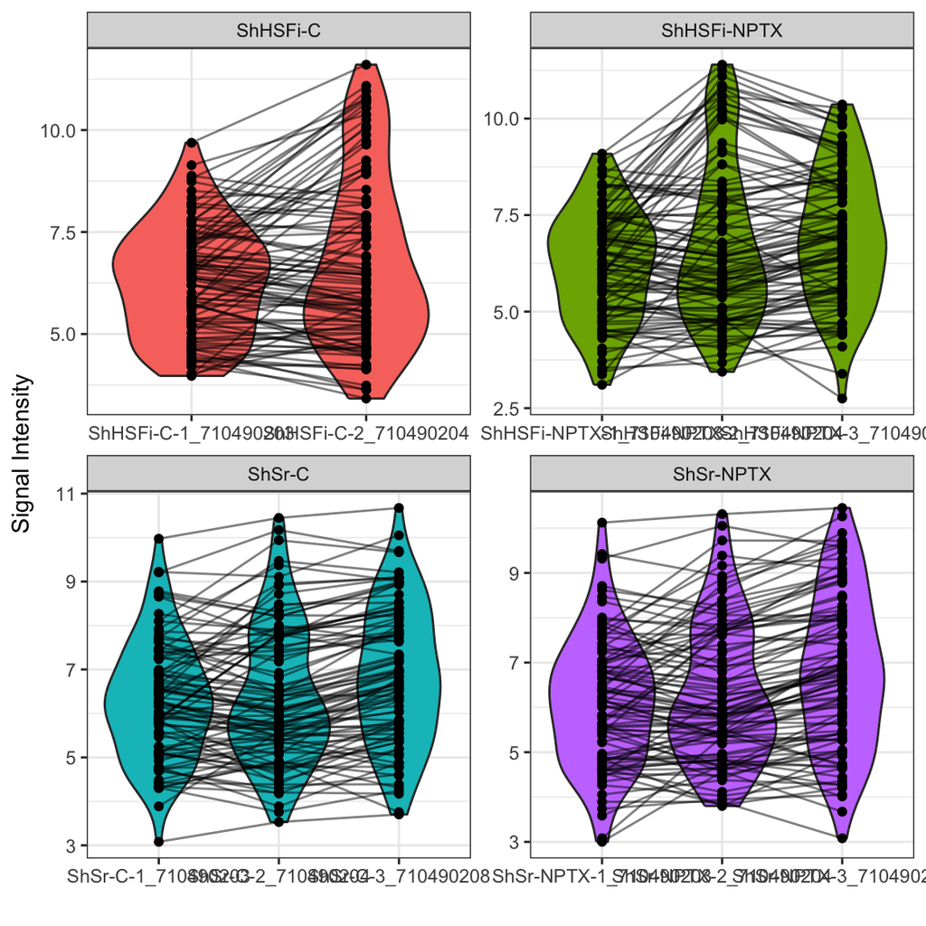

Violin Plots for signal intensity Distribution Across Groups for all replicates

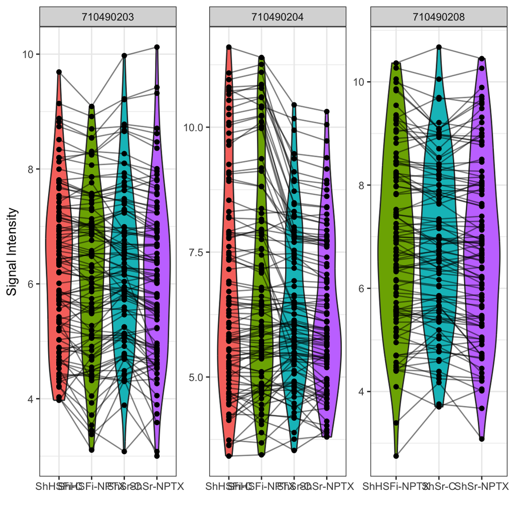

Violin Plots for signal intensity Distribution Across Chips for all replicates

## Group Comparison

To compare between samples, a two-group comparison is performed. In this case, there are three group comparisons:

The *Slope_Transformed* ratio between each group, paired by chip, is calculated to the fold change. Based on the fold change, peptides that pass a certain fold change threshold are considered significant hits. Also, quality control steps applied in each comparison to filter out peptides that do not reach specific criteria:

- The *Median_SigmBg* at max exposure *100ms* must be above a certain value
- $R^2$ of the linear model fit must be above a threshold value

These *Filtering Parameters* (fold change threshold, QC criteria) can be modified to adjust the stringency of the analysis. The *Filtering Parameters* that are used for this analysis:

- The *Median_SigmBg* at max exposure *100ms* must be equal or above 5
- $R^2$ of the linear model fit must be above or equal 0.8
- Log fold change (LFC) cutoffs at (0.2,0.3,0.4)

### ShSr-NPTX vs ShSr-C

#### Heatmap

After applying the *Filtering Parameters* for this group comparison, only *31*/141 peptides carried forward in the analysis (i.e. *31 hits*). Below are some figures to visualize the differences between these samples for considering these *hits*.

#### Violin Plot

Below, the violin plot visualizes the distribution of selected peptides for the analysis.

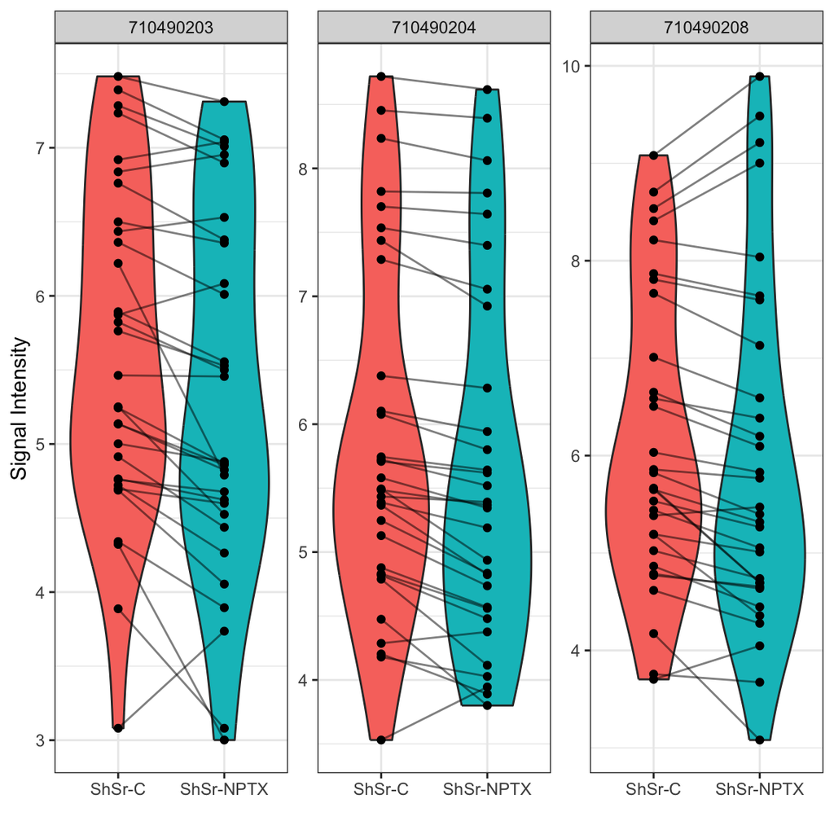

Violin plot of two groups

#### Waterfall Plot

This waterfall represents the log2 fold changes between the two groups at each peptide.

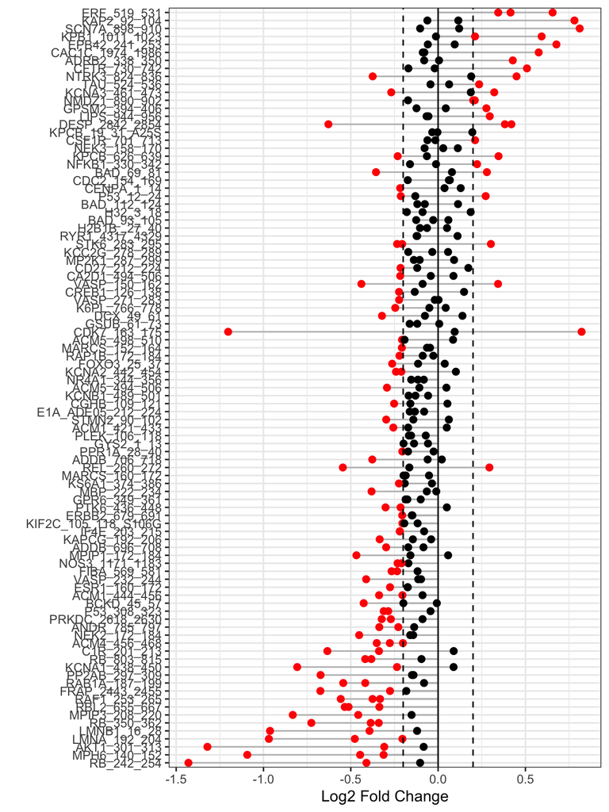

Waterfall Plot to show the distribution of change in peptide phosphorylation

#### Upstream Kinase Analysis

The lab carefully curated and mapped the kinases that can act and phosphorylate each peptide present on the chip. This was achieved by using multiple sources including GPS 3.0, Kinexus Phosphonet, PhosphoELM and PhosphoSite Plus. Based on that association between peptides and kinases, a random sampling analysis is performed for these hits. The basic idea of *KRSA* is: For each iteration (*2000* iterations performed in this analysis), the same number of hits are randomly selected from the total 141/or 193 peptides present on the chip. Predicted kinases are then mapped to this sample list of peptides and number of kinases are determined. The kinase count from the actual hits and random sampling is then compared to determine the significance.

| Kinase | AvgZ |
| --- | --- |
| MARK | 1.5875000 |
| PDK1 | 1.4725000 |
| CAMK1 | 1.3083333 |
| BRSK | 1.2508333 |
| P38 | 1.2108333 |
| MELK | 1.1133333 |
| DYRK | 1.1050000 |
| IRAK | 1.0316667 |
| RAD53 | 1.0175000 |
| CHK1 | 0.9733333 |
| ULK | -0.5550000 |
| ATM | -0.5566667 |
| SLK | -0.5575000 |
| RAF | -0.5741667 |
| NAK | -0.6658333 |
| COT | -0.7691667 |
| TLK | -0.7700000 |
| AKT | -0.7825000 |
| PKCD | -0.9300000 |
| NMO | -1.4391667 |

| Method | NumberOfPeptides |
| --- | --- |
| meanLFC.0.15 | 41 |
| meanLFC.0.2 | 31 |
| meanLFC.0.3 | 14 |
| meanLFC.0.4 | 10 |
| 710490203.0.15 | 52 |
| 710490203.0.2 | 42 |
| 710490203.0.3 | 25 |
| 710490203.0.4 | 13 |
| 710490204.0.15 | 52 |
| 710490204.0.2 | 35 |
| 710490204.0.3 | 15 |
| 710490204.0.4 | 9 |
| 710490208.0.15 | 58 |
| 710490208.0.2 | 46 |
| 710490208.0.3 | 29 |
| 710490208.0.4 | 19 |

#### Z Scores Plot

We will plot the individual and averaged Z scores using both the across and within chip analyses.

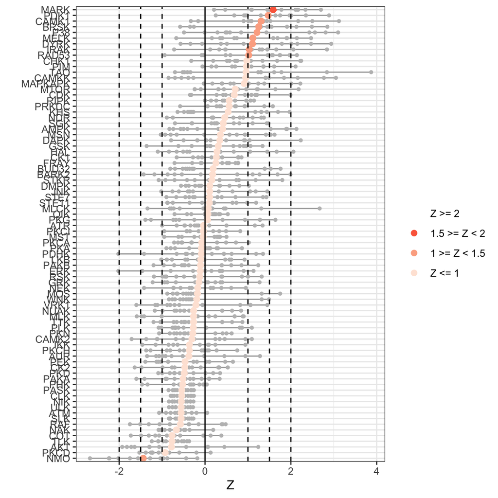

Waterfall plot of the Z Scores of each kinase family

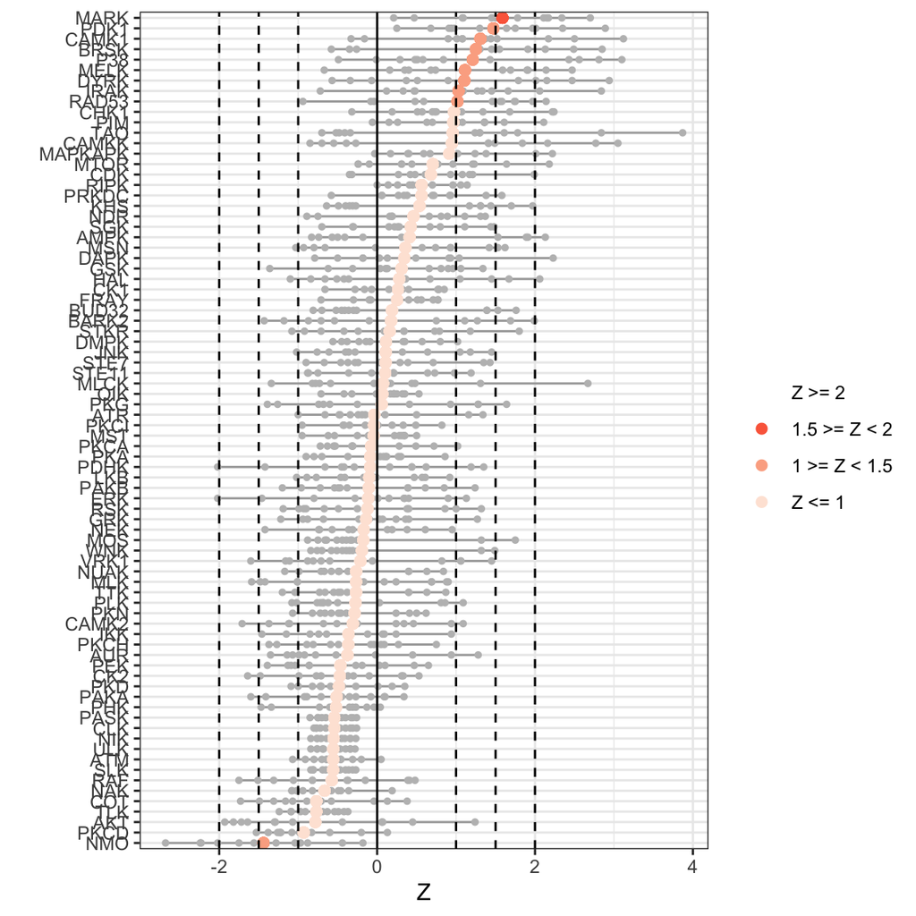

Waterfall plot of the Z Scores of each kinase family

#### Reverse KRSA Plot

We will use the reverse KRSA plot function, to plot the log2 fold change values for all peptides mapped to kinase hits. This will help us examine the activity of the kinase

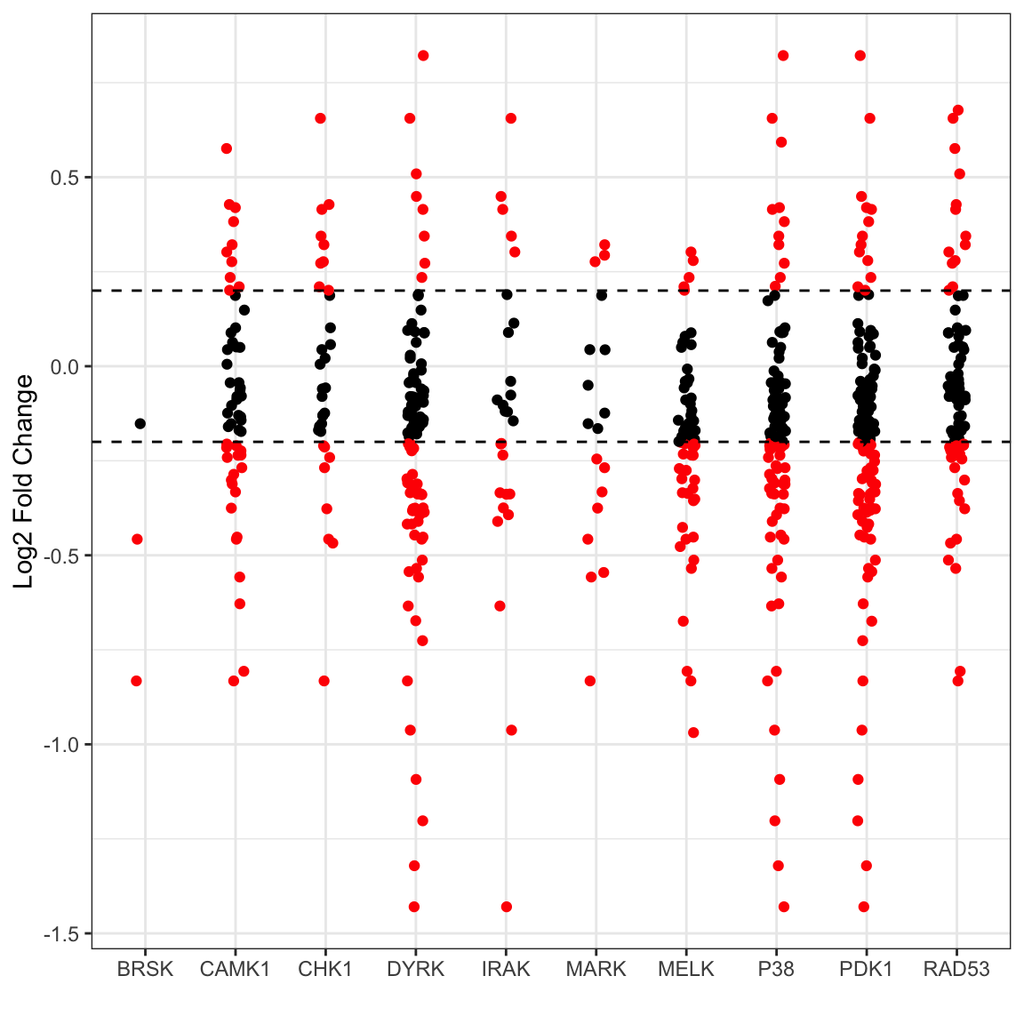

Kinase Activity summary for each kinase family based on peptide phosphorylation

#### Coverage Plot

To view the coverage of kinases across the full list of peptides on the chip, we will use the coverage plot function

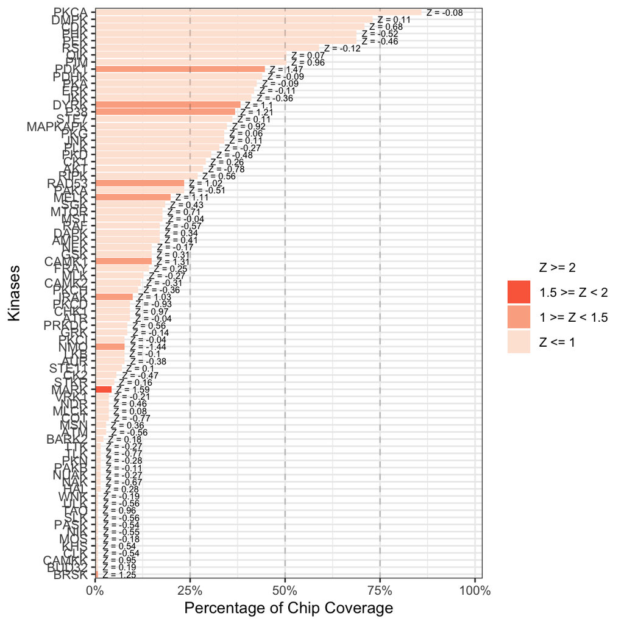

Percentage of peptides each kinase family phosphorylates

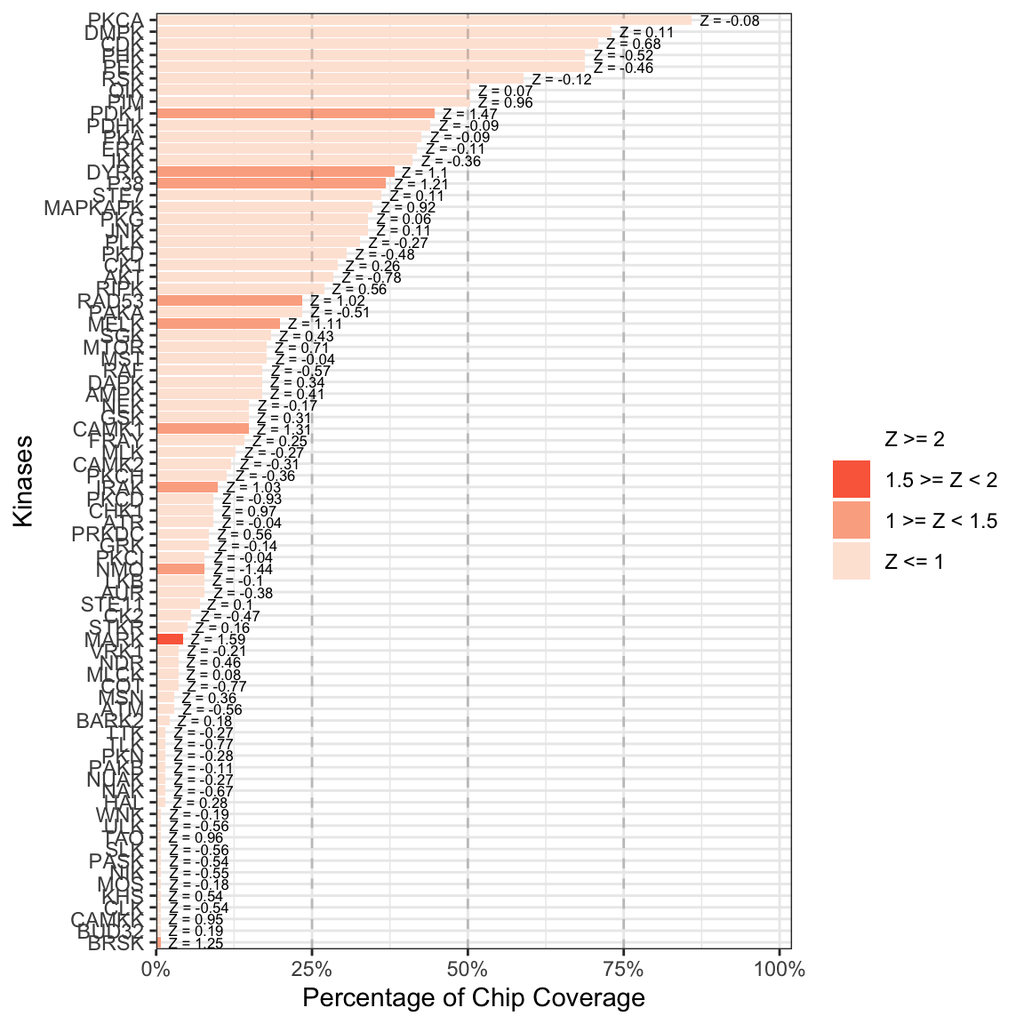

Percentage of peptides each kinase family phosphorylates

#### Ball Model Network

We will view the ball model network function, to generate a model representing the protein-protein interactions between kinases

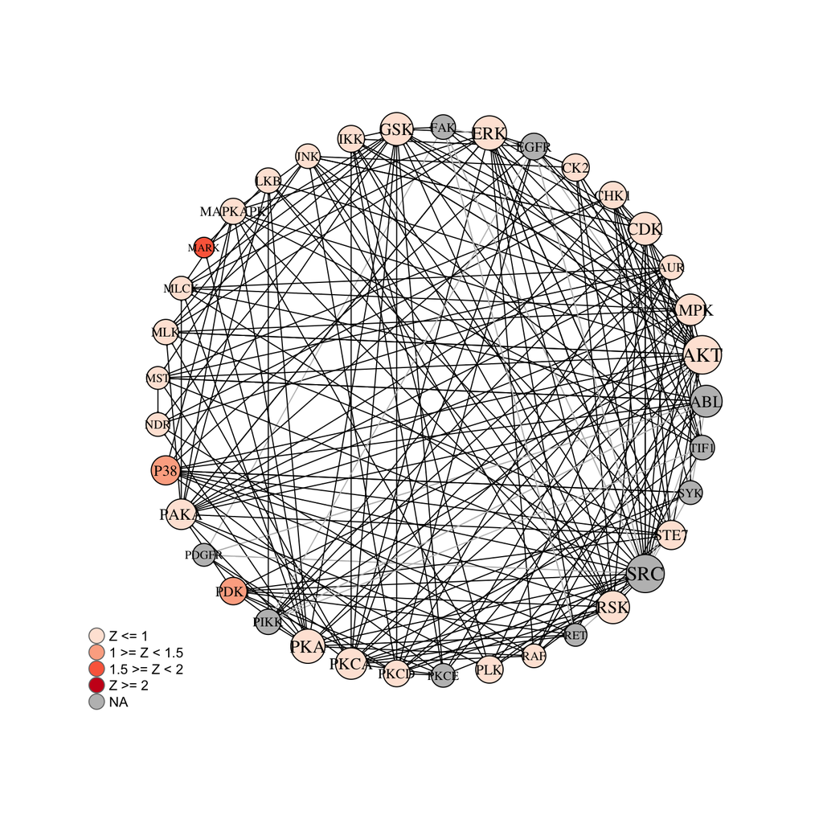

### ShHSFi-C vs ShSr-C

#### Heatmap

After applying the *Filtering Parameters* for this group comparison, only *44*/141 peptides carried forward in the analysis (i.e. *44 hits*). Below are some figures to visualize the differences between these samples for considering these *hits*.

#### Violin Plot

Below, the violin plot visualizes the distribution of selected peptides for the analysis.

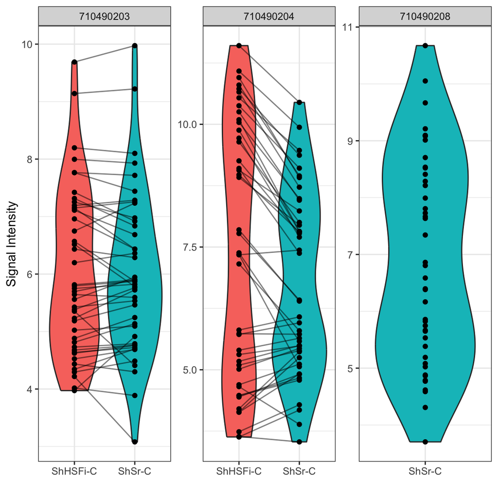

Violin plot of two groups

#### Waterfall Plot

This waterfall represents the log2 fold changes between the two groups at each peptide.

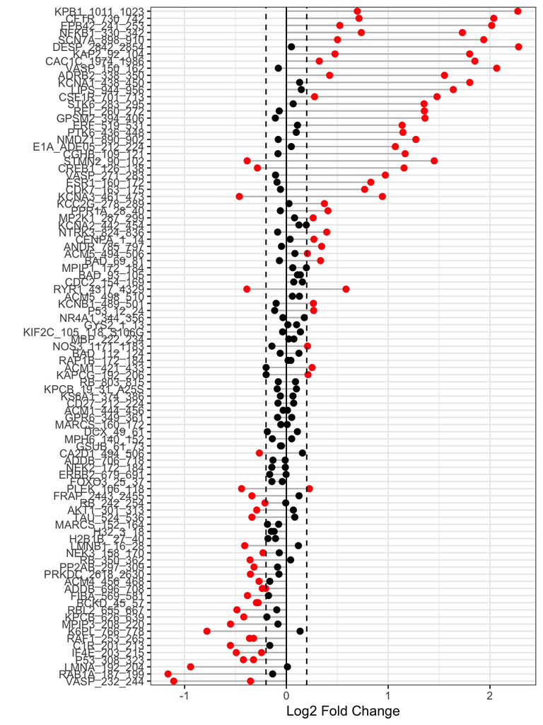

Waterfall Plot to show the distribution of change in peptide phosphorylation

#### Upstream Kinase Analysis

The lab carefully curated and mapped the kinases that can act and phosphorylate each peptide present on the chip. This was achieved by using multiple sources including GPS 3.0, Kinexus Phosphonet, PhosphoELM and PhosphoSite Plus. Based on that association between peptides and kinases, a random sampling analysis is performed for these hits. The basic idea of *KRSA* is: For each iteration (*2000* iterations performed in this analysis), the same number of hits are randomly selected from the total 141/or 193 peptides present on the chip. Predicted kinases are then mapped to this sample list of peptides and number of kinases are determined. The kinase count from the actual hits and random sampling is then compared to determine the significance.

| Kinase | AvgZ |
| --- | --- |
| PKG | 2.32625 |
| PKA | 2.21000 |
| CAMK1 | 2.06250 |
| MARK | 1.94750 |
| KHS | 1.72625 |
| HAL | 1.66125 |
| RAD53 | 1.36000 |
| DMPK | 1.32750 |
| MAPKAPK | 1.18250 |
| RIPK | 1.17875 |
| TLK | -0.86625 |
| RAF | -0.97125 |
| DYRK | -0.99875 |
| FRAY | -1.08500 |
| PEK | -1.13375 |
| NEK | -1.21375 |
| PDK1 | -1.37375 |
| JNK | -1.40625 |
| ERK | -1.66500 |
| NMO | -1.68750 |

| Method | NumberOfPeptides |
| --- | --- |
| meanLFC.0.15 | 51 |
| meanLFC.0.2 | 44 |
| meanLFC.0.3 | 36 |
| meanLFC.0.4 | 27 |
| 710490203.0.15 | 43 |
| 710490203.0.2 | 35 |
| 710490203.0.3 | 24 |
| 710490203.0.4 | 14 |
| 710490204.0.15 | 59 |
| 710490204.0.2 | 52 |
| 710490204.0.3 | 42 |
| 710490204.0.4 | 35 |

#### Z Scores Plot

We will plot the individual and averaged Z scores using both the across and within chip analyses.

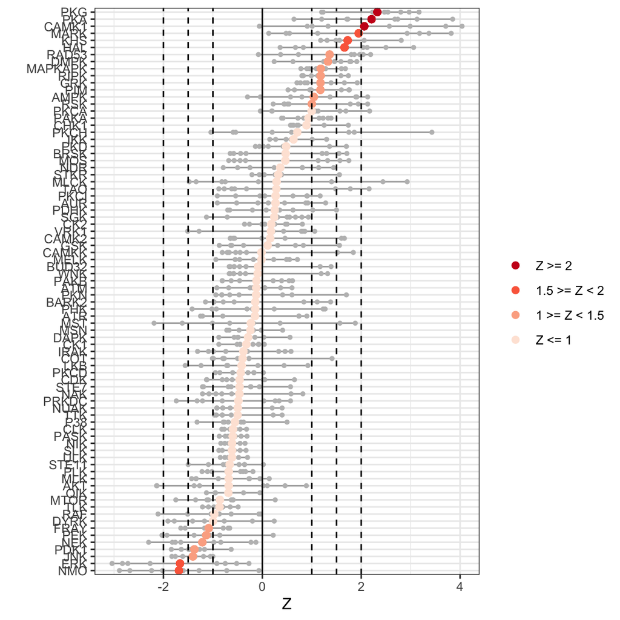

Waterfall plot of the Z Scores of each kinase family

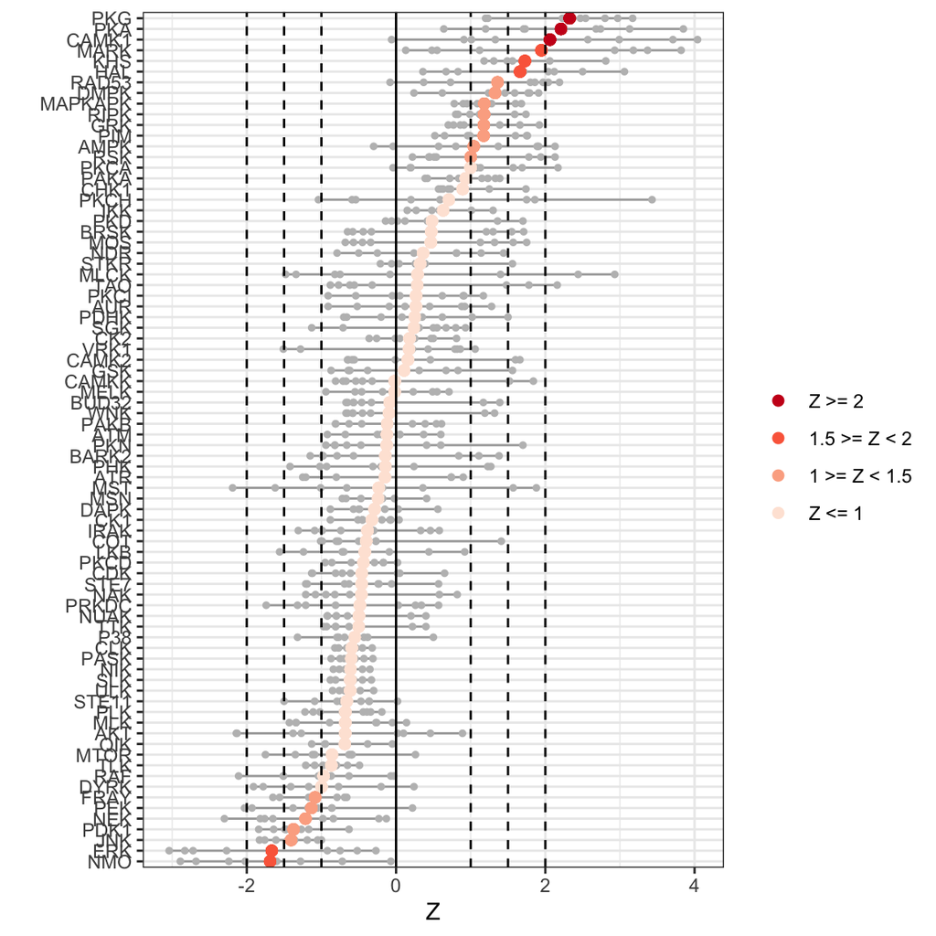

Waterfall plot of the Z Scores of each kinase family

#### Reverse KRSA Plot

We will use the reverse KRSA plot function, to plot the log2 fold change values for all peptides mapped to kinase hits. This will help us examine the activity of the kinase

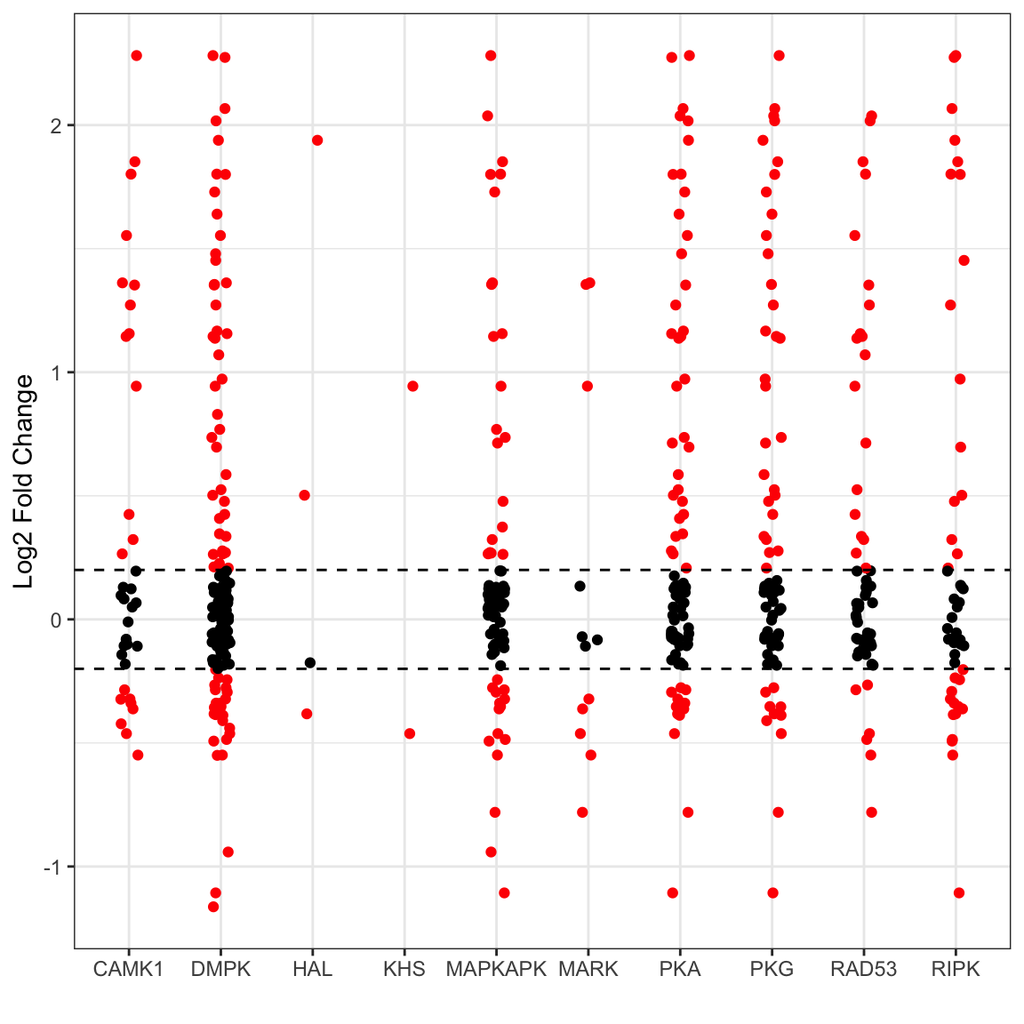

Kinase Activity summary for each kinase family based on peptide phosphorylation

#### Coverage Plot

To view the coverage of kinases across the full list of peptides on the chip, we will use the coverage plot function

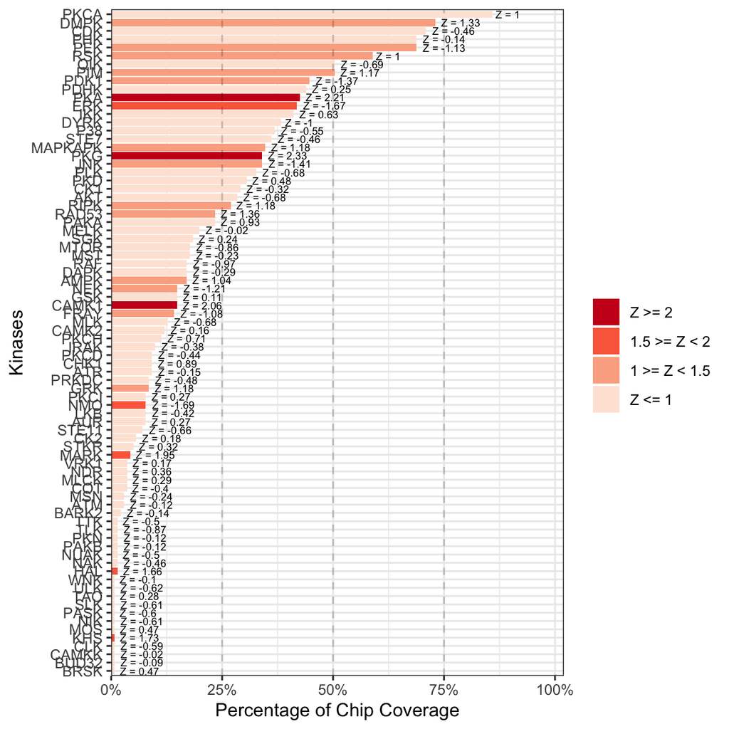

Percentage of peptides each kinase family phosphorylates

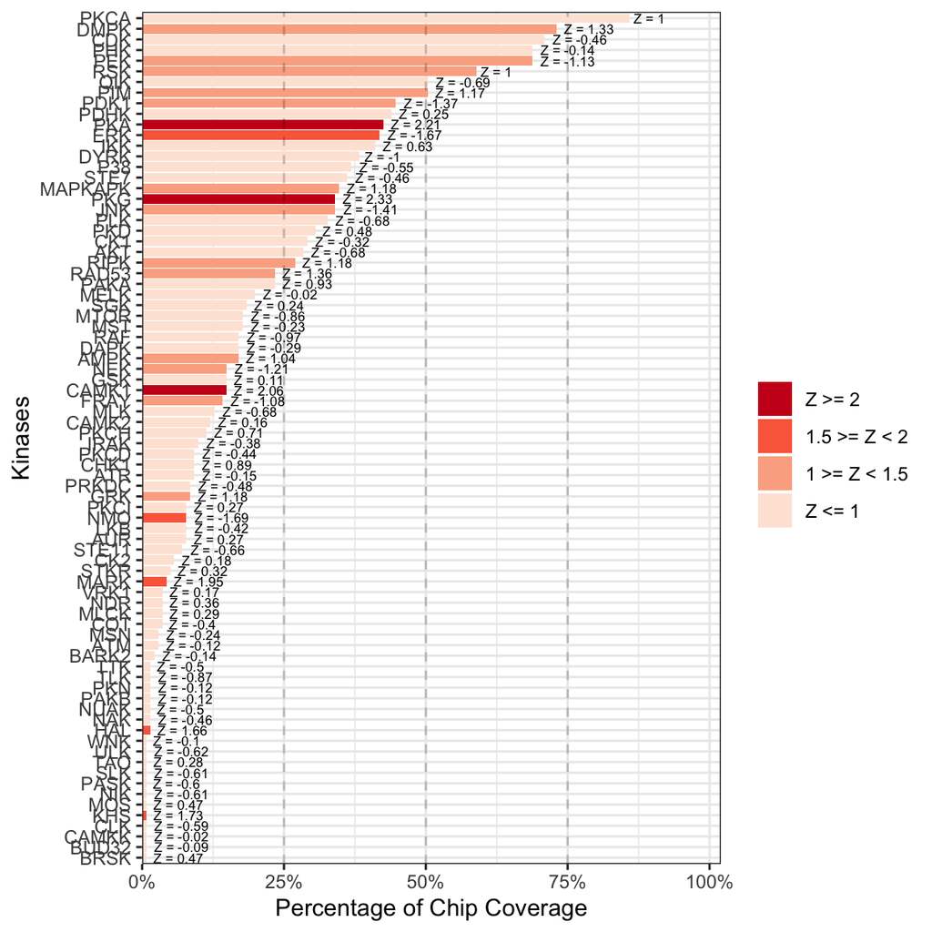

Percentage of peptides each kinase family phosphorylates

#### Ball Model Network

We will view the ball model network function, to generate a model representing the protein-protein interactions between kinases

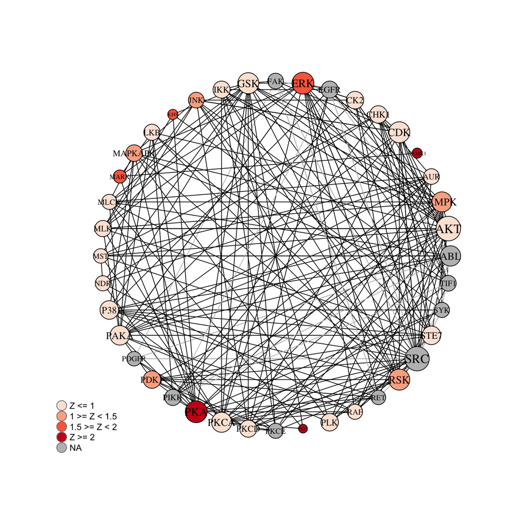

### ShHSFi-NPTX vs ShSr-C

After applying the *Filtering Parameters* for this group comparison, only *44*/141 peptides carried forward in the analysis (i.e. *44 hits*). Below are some figures to visualize the differences between these samples for considering these *hits*.

#### Violin Plot

Below, the violin plot visualizes the distribution of selected peptides for the analysis.

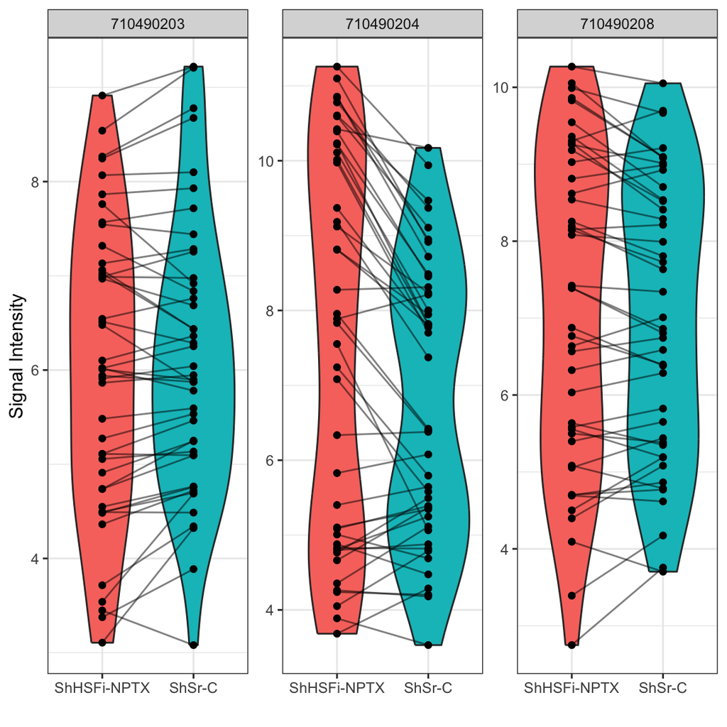

Violin plot of two groups

#### Waterfall Plot

This waterfall represents the log2 fold changes between the two groups at each peptide.

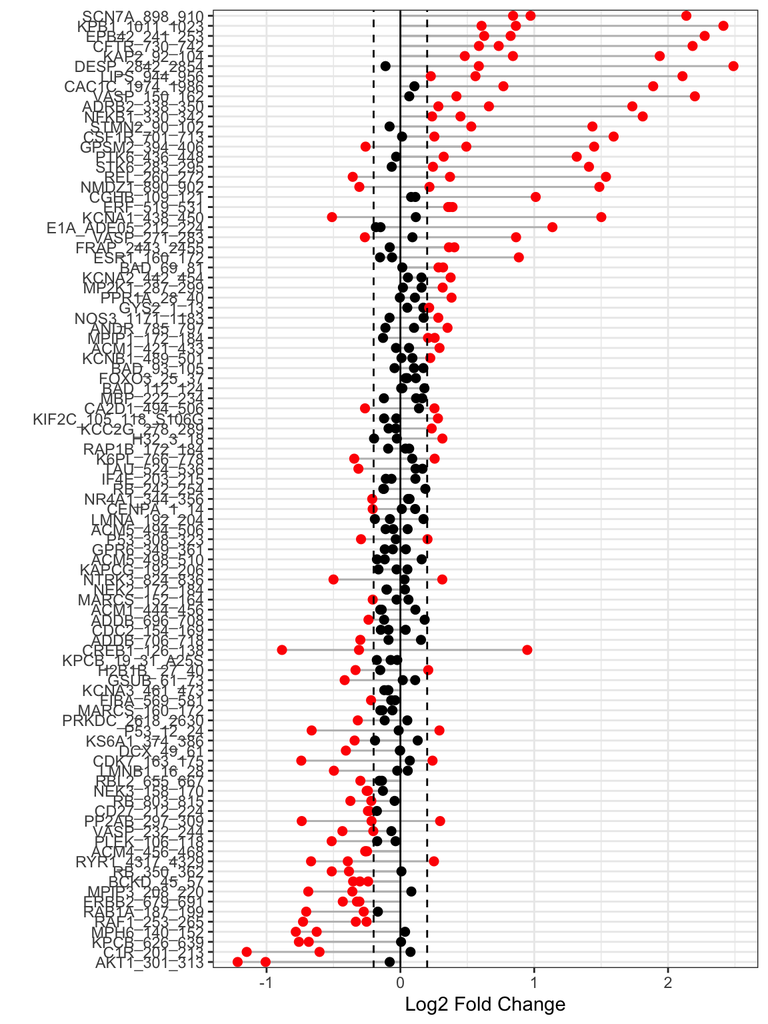

Waterfall Plot to show the distribution of change in peptide phosphorylation

#### Upstream Kinase Analysis

The lab carefully curated and mapped the kinases that can act and phosphorylate each peptide present on the chip. This was achieved by using multiple sources including GPS 3.0, Kinexus Phosphonet, PhosphoELM and PhosphoSite Plus. Based on that association between peptides and kinases, a random sampling analysis is performed for these hits. The basic idea of *KRSA* is: For each iteration (*2000* iterations performed in this analysis), the same number of hits are randomly selected from the total 141/or 193 peptides present on the chip. Predicted kinases are then mapped to this sample list of peptides and number of kinases are determined. The kinase count from the actual hits and random sampling is then compared to determine the significance.

| Kinase | AvgZ |
| --- | --- |
| PKA | 2.0741667 |
| PKG | 2.0041667 |
| CAMK1 | 1.7950000 |
| AMPK | 1.6358333 |
| PIM | 1.6008333 |
| MARK | 1.5866667 |
| RAD53 | 1.5658333 |
| RSK | 1.3058333 |
| CHK1 | 1.0283333 |
| HAL | 1.0100000 |
| FRAY | -0.9608333 |
| PLK | -0.9975000 |
| P38 | -1.0391667 |
| RAF | -1.0808333 |
| PDK1 | -1.1558333 |
| NEK | -1.2016667 |
| PEK | -1.4991667 |
| JNK | -1.6858333 |
| ERK | -1.7166667 |
| NMO | -1.9408333 |

| Method | NumberOfPeptides |
| --- | --- |
| meanLFC.0.15 | 49 |
| meanLFC.0.2 | 44 |
| meanLFC.0.3 | 29 |
| meanLFC.0.4 | 24 |
| 710490203.0.15 | 56 |
| 710490203.0.2 | 49 |
| 710490203.0.3 | 28 |
| 710490203.0.4 | 19 |
| 710490204.0.15 | 62 |
| 710490204.0.2 | 54 |
| 710490204.0.3 | 41 |
| 710490204.0.4 | 31 |
| 710490208.0.15 | 54 |
| 710490208.0.2 | 42 |
| 710490208.0.3 | 29 |
| 710490208.0.4 | 18 |

#### Z Scores Plot

We will plot the individual and averaged Z scores using both the across and within chip analyses.

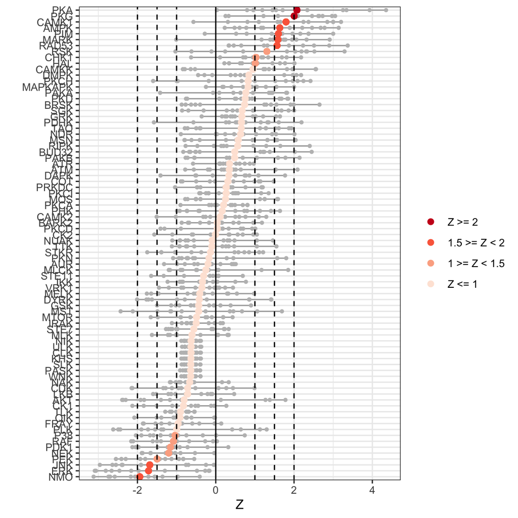

Waterfall plot of the Z Scores of each kinase family

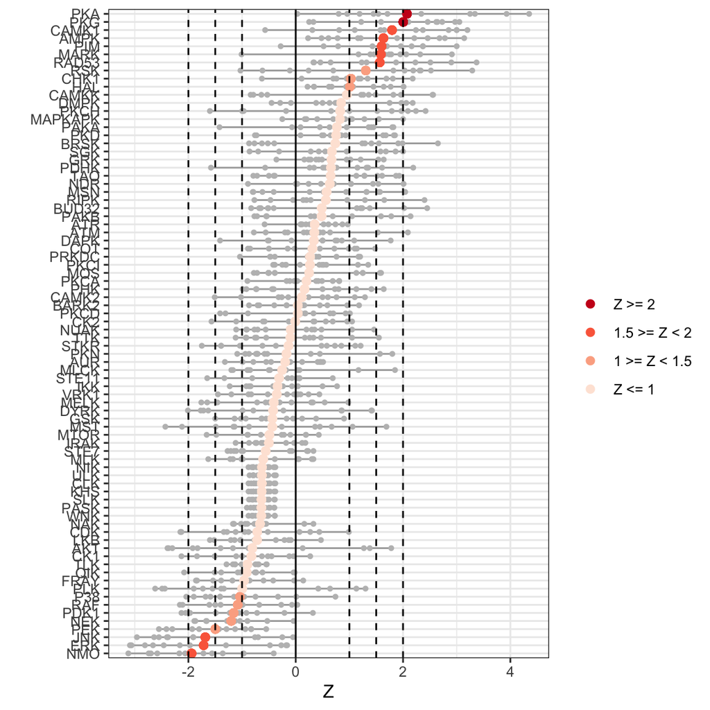

Waterfall plot of the Z Scores of each kinase family

#### Reverse KRSA Plot

We will use the reverse KRSA plot function, to plot the log2 fold change values for all peptides mapped to kinase hits. This will help us examine the activity of the kinase

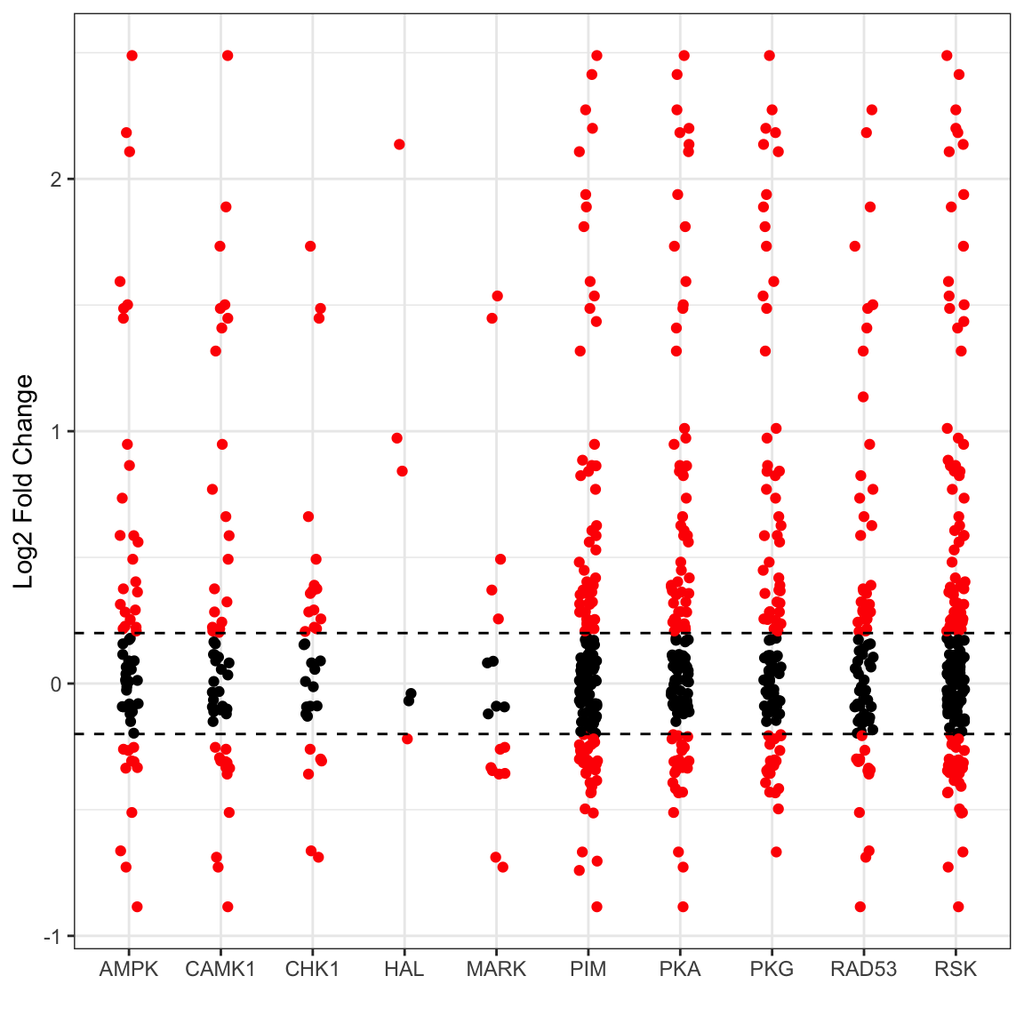

Kinase Activity summary for each kinase family based on peptide phosphorylation

#### Coverage Plot

To view the coverage of kinases across the full list of peptides on the chip, we will use the coverage plot function

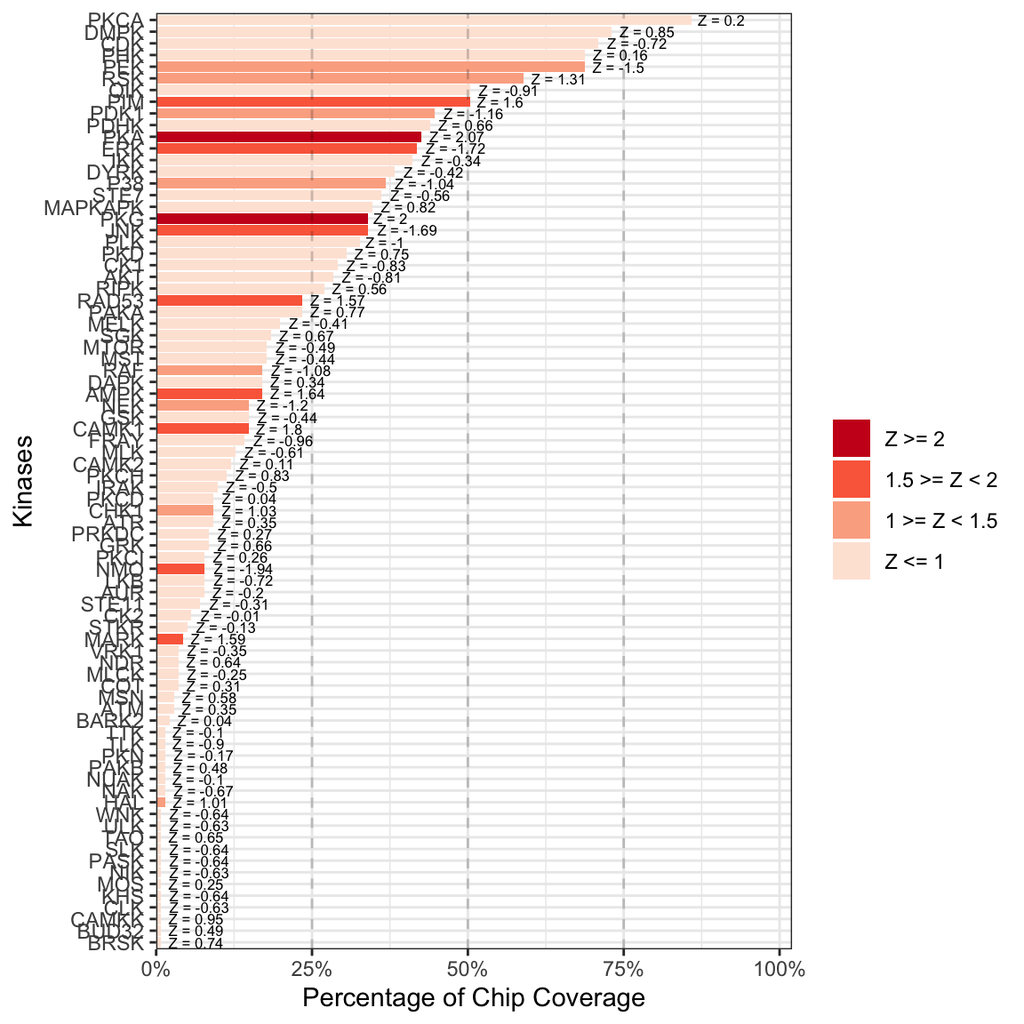

Percentage of peptides each kinase family phosphorylates

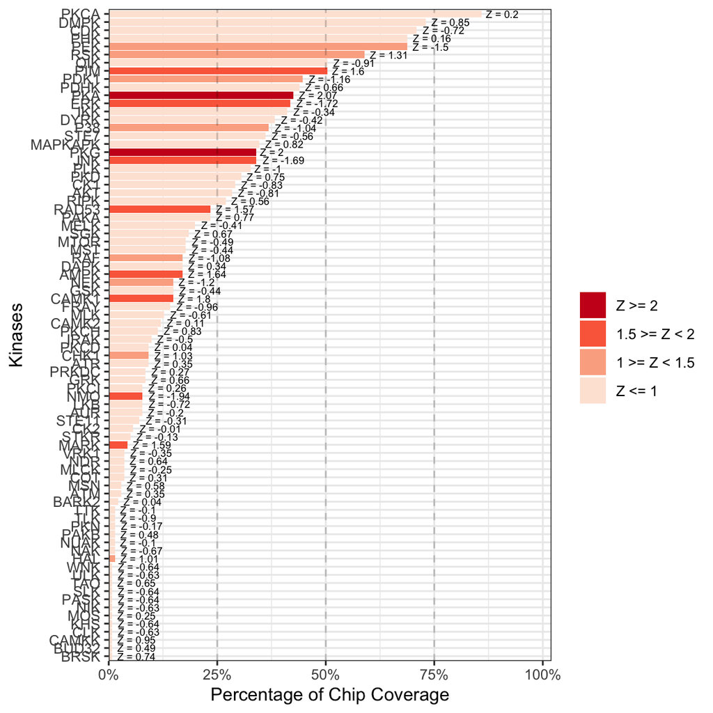

Percentage of peptides each kinase family phosphorylates

#### Ball Model Network

We will view the ball model network function, to generate a model representing the protein-protein interactions between kinases

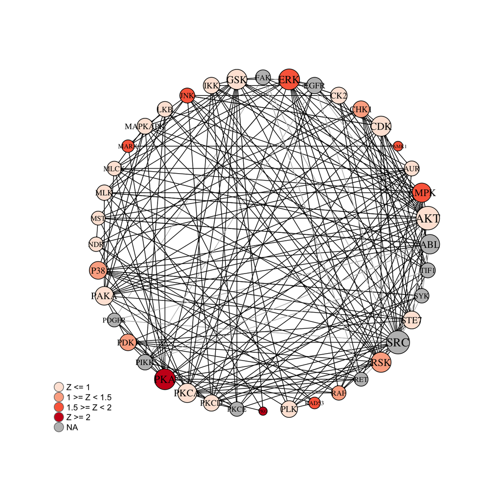

### ShHSFi-NPTX vs ShHSFi-C

After applying the *Filtering Parameters* for this group comparison, only *23*/141 peptides carried forward in the analysis (i.e. *23 hits*). Below are some figures to visualize the differences between these samples for considering these *hits*.

#### Violin Plot

Below, the violin plot visualizes the distribution of selected peptides for the analysis.

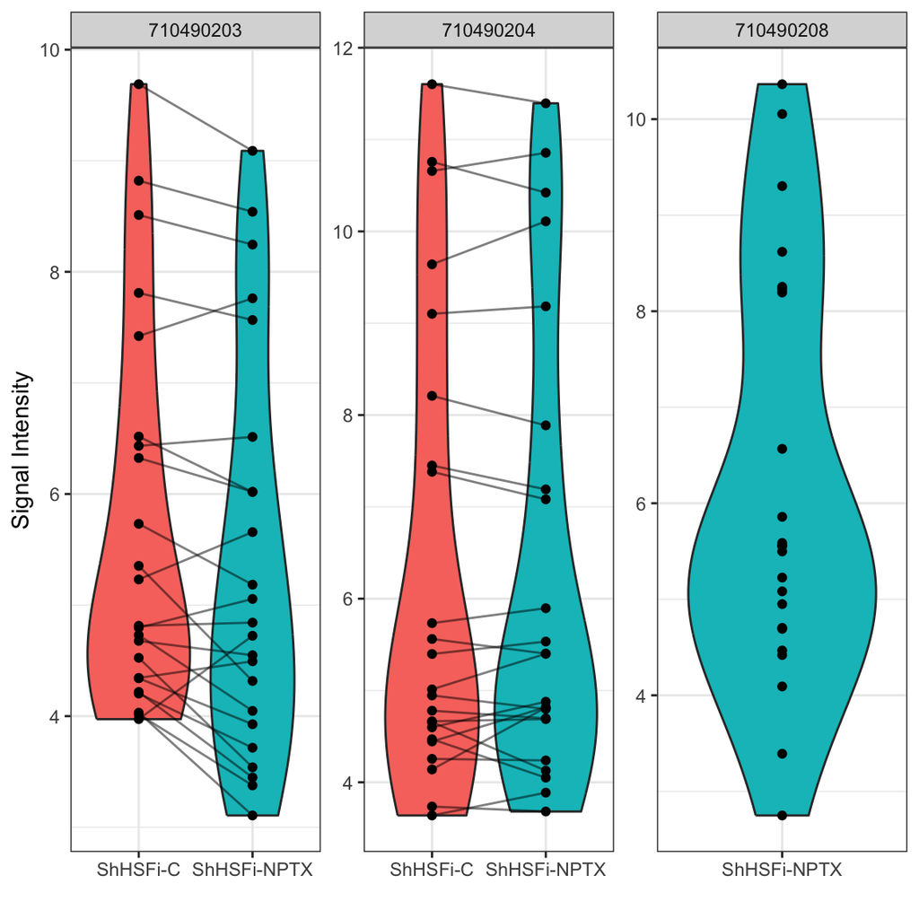

Violin plot of two groups

#### Waterfall Plot

This waterfall represents the log2 fold changes between the two groups at each peptide.

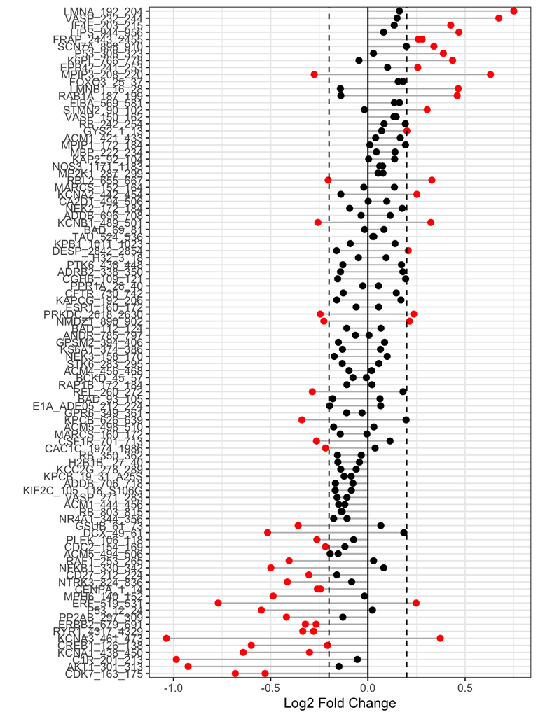

Waterfall Plot to show the distribution of change in peptide phosphorylation

#### Upstream Kinase Analysis

The lab carefully curated and mapped the kinases that can act and phosphorylate each peptide present on the chip. This was achieved by using multiple sources including GPS 3.0, Kinexus Phosphonet, PhosphoELM and PhosphoSite Plus. Based on that association between peptides and kinases, a random sampling analysis is performed for these hits. The basic idea of *KRSA* is: For each iteration (*2000* iterations performed in this analysis), the same number of hits are randomly selected from the total 141/or 193 peptides present on the chip. Predicted kinases are then mapped to this sample list of peptides and number of kinases are determined. The kinase count from the actual hits and random sampling is then compared to determine the significance.

| Kinase | AvgZ |
| --- | --- |
| MARK | 2.39625 |
| MAPKAPK | 1.93500 |
| KHS | 1.84625 |
| CAMK1 | 1.73375 |
| CHK1 | 1.70625 |
| BRSK | 1.61125 |
| STKR | 1.48125 |
| AMPK | 1.37500 |
| MOS | 1.06375 |
| BUD32 | 0.85625 |
| PDHK | -0.49750 |
| FRAY | -0.57000 |
| STE11 | -0.65875 |
| PKN | -0.66375 |
| TLK | -0.66500 |
| AKT | -0.72000 |
| RAF | -0.86125 |
| PEK | -0.88375 |
| PAKA | -1.14000 |
| NMO | -1.22500 |

| Method | NumberOfPeptides |
| --- | --- |
| meanLFC.0.15 | 34 |
| meanLFC.0.2 | 23 |
| meanLFC.0.3 | 9 |
| meanLFC.0.4 | 7 |
| 710490203.0.15 | 50 |
| 710490203.0.2 | 31 |
| 710490203.0.3 | 20 |
| 710490203.0.4 | 15 |
| 710490204.0.15 | 44 |
| 710490204.0.2 | 28 |
| 710490204.0.3 | 15 |
| 710490204.0.4 | 8 |